# Text_attentive_char_biLSTM_score_regression

**Reading recommendation**

Since I am very methodical this notebook is well structured, very detailed and quite long. **I warmly recommend reading this notebook with an *interactive table of contents side-panel*** for convenient navigation. Jupyter with [jupyter_contrib_nbextensions](https://jupyter-contrib-nbextensions.readthedocs.io/en/latest/index.html) supports these and many more useful perks (I warmly recommend!), but they are unsupported in Git or a normal Jupyter, so -

**Ways to view this notebook with an interactive navigation side-panel:**

- **Easiest and fastest:** view [this notebook in html](https://github.com/Ozziko/DatingAI/blob/master/Text_attentive_char_biLSTM_score_regression.html). Git does not support viewing it online, so you can download it to your computer and open.
- Download this notebook and view on Google Colab.
- Best for you in long term: view this notebook in Jupyter notebook with *jupyter_contrib_nbextensions* installed (learn how [here](https://jupyter-contrib-nbextensions.readthedocs.io/en/latest/install.html)).

# Intro

Author: oz.livneh@gmail.com

- All rights of this project and my code are reserved to me, Oz Livneh.
- Feel free to use - for personal use!
- Use at your own risk 😉

## Project description

DatingAI is a personal research project that I started for my interest, challenge and experience, and also to demonstrate my skills (*recently I'm looking for a job or interesting offers*), aiming to:

1. **Learn personal taste in dating sites:**
   1. How to predict personal taste (represented by the scores that a user gives to profiles) by neural networks.
   2. How different profile features - images, numerical/categorical features (age, location...), text - affect the personal taste of a user.
   3. How to represent personal taste and profile embedding, what clusters exist and how they depend on the scoring scale...
2. **Develop a personal dating agent** that automatically likes/passes and messages profiles according to the user personal taste learned.

## Notebook description

The architecture presented in this notebook **predicts the user score given for each dating profile based on the free text that is written in the profile**, which is weakly-structured - there are many kinds of optional sections to fill freely, e.g. 'My self-summary', "What I'm doing with my life", 'I value', etc.

## Architecture scheme

1. The text on each section is encoded by a **character level bi-LSTM**, since I deal with text of Israeli profiles - intertwined English, Hebrew & Emojis, where Hebrew is right-to-left, and highly inflected (which makes it highly efficient).
2. An **attention net** summarizes all sections in each profile, where the inputs for each section are the embedding of the section headline and the bi-LSTM state vector achieved by operating on the section text.
3. A final **batch regression net** transforms the final attention output into a profile score. It operates on a batch of profiles - where each profile passes through an attention net, and outputs a batch of profile scores.

[figure not shown]

## Data scheme

```
essay_dict={'My self-summary':'some general quote and 😉',
            'Some rare headline':'some text 🙃',
            ...
            "What I'm doing with my life":'איזה חרטוט כללי 🕺💃 Yo ho!'}
```

**$\to$ headline and character tokenization:**

```
essay_dict={'My self-summary':['s','o','m','e',' ','g','e','n','e','r','a','l',' ','q','u','o','t','e','
                                ','a','n','d',' ','😉'],
            'UNK':['s','o','m','e',' ','t','e','x','t',' ','UNK'],
            ...,
            "What I'm doing with my life":['ח','ר','ט','ו','ט',' ','כ','ל','ל','י',' ','UNK','💃',' ',
                                'Y','o',' ','h','o','UNK']}
```

**$\to$ headline and character embedding:**

```
tokenized_ids_essay_dict={16:[15,33,62,10,...],
                    21:[8,63,11,100,...],
                    ...
                    56:[...]}
```

$\to$ my custom batching for essay dictionaries:

```
tokenized_ids_essay_dict_list=batch['essay dict tokenized ids']

tokenized_ids_essay_dict_list=[profile_essay_dict_1,profile_essay_dict_2,...,profile_essay_dict_n]

len(tokenized_ids_essay_dict_list)=batch_size
```

# Initialization

## Key system requirements

```python
import torch
print('torch\t\ttested on 1.3\t\tcurrent:',torch.__version__)

import sys
print('Python\t\ttested on 3.7.3\t\tcurrent:',sys.version[:sys.version.find(' ')])
import numpy as np
print('numpy\t\ttested on 1.16.4\tcurrent:',np.__version__)
import pandas as pd
print('pandas\t\ttested on 0.24.2\tcurrent:',pd.__version__)

import matplotlib
print('matplotlib\ttested on 3.1.0\t\tcurrent:',matplotlib.__version__)
```

```
torch		tested on 1.3		current: 1.3.0
Python		tested on 3.7.3		current: 3.7.3
numpy		tested on 1.16.4	current: 1.16.4
pandas		tested on 0.24.2	current: 0.24.2
matplotlib	tested on 3.1.0		current: 3.1.0
```

## Setting main parameters

```python
#--------- general -------------
debugging=True # executes the debugging (short) sections, prints results
#debugging=False
torch_manual_seed=0 # integer or None for no seed; for torch reproducibility, as much as possible
#torch_manual_seed=None

#--------- data -------------
data_folder_path=r'D:\AI Data\DatingAI\Data'
df_pickle_file_name='profiles_df.pickle'

"""
dataset downsampling (samples = profiles):
    if max_dataset_length>0: builds a dataset by sampling only
        max_dataset_length samples from all available data.
        requires user approval!
    if max_dataset_length<=0: not restricting dataset length - using all
        available data
"""
max_dataset_length=1000 # if positive: builds a dataset by sampling only max_dataset_length samples from all available data; requires user approval
# max_dataset_length=0 # if non-positive: not restricting dataset length - using all available data
seed_for_dataset_downsampling=0 # integer or None for no seed; for sampling max_dataset_length samples from dataset

validation_ratio=0.5 # validation dataset ratio from total dataset length

batch_size_int_or_ratio_float=8 # if int: each batch will contain this number of samples
#batch_size_int_or_ratio_float=1e-2 # if float: batch_size=round(batch_size_over_dataset_length*len(dataset_to_split))
data_workers=0 # 0 means no multiprocessing in dataloaders
#data_workers='cpu cores' # sets data_workers=multiprocessing.cpu_count()

shuffle_dataset_indices_for_split=True # dataset indices for dataloaders are shuffled before splitting to train and validation indices
#shuffle_dataset_indices_for_split=False
dataset_shuffle_random_seed=0 # numpy seed for sampling the indices for the dataset, before splitting to train and val dataloaders
#dataset_shuffle_random_seed=None
dataloader_shuffle=True # samples are shuffled inside each dataloader, on each epoch
#dataloader_shuffle=False

#--------- vocabulary/tokenizing parameters -------------
lower_chars=False
cumulative_portion_to_cover_with_headline_vocab=0.98
cumulative_portion_to_cover_with_char_vocab=0.98
tokens_to_force_into_char_vobac=list('0123456789')
tokens_to_force_into_char_vobac.append('<br/>')

#--------- net parameters -------------
headline_embedding_dim=3 # expect headline vocabulary length of ~80
char_embedding_dim=4 # expect char vocabulary length of ~100
bidirectional=True # for the LSTM net; True is expected for right-to-left languages, and even useful elsewhere
LSTM_layers=1
LSTM_hidden_size=24
attention_size=4

loss_name='MSE, reduction: sum' # MSE loss, the loss is summed for all samples on which it operates

#--------- training -------------
train_model_else_load_weights=True
#train_model_else_load_weights=False # instead of training, loads a pre-trained model and uses it

force_train_evaluation_after_each_epoch=True # adding evaluation of the training dataset after each epoch finishes training
# force_train_evaluation_after_each_epoch=False # default
pre_training_evaluation=True # pre-training evaluation of trainnig and validation data
# pre_training_evaluation=False

epochs=10

# learning_rate=2e-3
# optimizer_name='SGD'
# SGD_momentum=0.7 # default: 0.9

learning_rate=1e-3
optimizer_name='Adam'
Adam_betas=(0.9,0.99) # default: (0.9,0.999)

lr_scheduler_decay_factor=0.99 # applies to all optimizers; on each lr_scheduler_step_size epochs, learning_rate*=lr_scheduler_decay_factor
lr_scheduler_step_size=1

best_model_criterion='min val epoch MSE' # criterion for choosing best net weights during training as the final weights
return_to_best_weights_in_the_end=True # when training complets, loads weights of the best net, definied by best_model_criterion
#return_to_best_weights_in_the_end=False

period_in_seconds_to_log_loss=30 # <=0 means no logging during training, else: inter-epoch logging and reporting loss and metrics during training
#plot_realtime_stats_on_logging=True # incomplete implementation!
plot_realtime_stats_on_logging=False
#plot_realtime_stats_after_each_epoch=True
plot_realtime_stats_after_each_epoch=False
#plot_y_in_log_scale=True
plot_y_in_log_scale=False

#offer_mode_saving=True # offer model weights saving ui after training (only if train_model_else_load_weights=True)
offer_mode_saving=False
models_folder_path='D:\My Documents\Dropbox\Python\DatingAI\Data\Saved Models'
```

## Imports

```python
import logging
logging.basicConfig(format='%(asctime)s %(funcName)s (%(levelname)s): %(message)s',
                   datefmt='%Y-%m-%d %H:%M:%S')
logger=logging.getLogger('main logger')
logger.setLevel(logging.INFO)

import os
import pandas as pd
pd.set_option('display.max_columns',7)
import numpy as np
import matplotlib.pyplot as plt
import random
from time import time
import copy
import multiprocessing
if data_workers=='cpu cores':
    data_workers=multiprocessing.cpu_count()
from collections import Counter

import torch
torch.manual_seed(torch_manual_seed)
import torch.utils.data as ptdata
import torch.nn as nn
import torch.nn.functional as F

import DatingAI
DatingAI.torch.manual_seed(torch_manual_seed)
device=DatingAI.device
```

```
2019-11-09 23:37:09 <module> (INFO): torch is using cuda:0 (GeForce GTX 960M)
2019-11-09 23:37:09 <module> (INFO): DatingAI imported
```

```python
# a charm for interactive plotting in Jupyter notebook (useful for zooming, rotating 3D plots):
%matplotlib notebook
```

# Pre-processing data, analysis

## Reading data

Reading profiles_df, the output of my Personal Cupid Scraper (*script_Personal_cupid_scraper.py*).

The data is personal, so it is not included in my Git but read from a local destination. **Anyone can execute *script_Personal_cupid_scraper.py* to score profiles and create his/her own data for training and prediction!**

```python
profiles_df_path=os.path.join(data_folder_path,df_pickle_file_name)
profiles_df=pd.read_pickle(profiles_df_path)

# finding score column (column name in the format of 'score (levels=%d)'%score_levels)
score_column_name=None
for column in profiles_df.columns:
    if 'score' in column:
        score_column_name=column
        break
if score_column_name==None:
    raise RuntimeError("no existing column name in profiles_df contains 'score'!")

simplified_columns=[] # original profiles_df names, except for 'score (levels=%d)'%max_level column which is replaced in 'profile score'
for col in profiles_df.columns:
    if 'score' in col:
        simplified_columns.append('profile score')
    else:
        simplified_columns.append(col)
profiles_df.columns=simplified_columns

if max_dataset_length>0 and max_dataset_length<len(profiles_df):
    user_data_approval=input('ATTENTION: downsampling is chosen - building a dataset by sampling only max_dataset_length=%d samples from all available data! approve? y/[n] '%(round(max_dataset_length)))
    if user_data_approval!='y':
        raise RuntimeError('user did not approve dataset max_dataset_length sampling!')
    random.seed(seed_for_dataset_downsampling)
    sampled_indices=random.sample(range(len(profiles_df)),max_dataset_length)
    profiles_df=profiles_df.iloc[sampled_indices]

logger.info('read profiles_df of length %d'%(len(profiles_df)))
```

```
ATTENTION: downsampling is chosen - building a dataset by sampling only max_dataset_length=1000 samples from all available data! approve? y/[n] y
```

```
2019-11-09 23:37:09 <module> (INFO): read profiles_df of length 1000
```

## Debugging: exploring data

```python
samples_num_to_verify=8
samples_verification_seed=0
#samples_verification_seed=None # None means no pre-set seed
# end of inputs ---------------------------------------------------------------
if debugging:
    random.seed(samples_verification_seed)
    sampled_indices_list=random.sample(range(len(profiles_df)),samples_num_to_verify)
    for i_profile in sampled_indices_list:
        essay_dict=profiles_df['essay dict'].iloc[i_profile]
        print(f'profile {i_profile} essay dict:',essay_dict)
        print('-'*50)
```

```
profile 864 essay dict: {'My self-summary': '<p>אני בן אדם טוב ומצחיקה...  הייתי מעדיפה לא להיות פה לצערי התאלמנתי. הייתי מעדיפה שלא. נותנת הזדמנות נוספת לחיים. זה לא פשוט אבל משתדלת להצליח.  מורה לציור. שומרת את השאר לשיחה🙊  לא מעשנת ולא עושה סמים וזה די מפריע לי... סורי 🙏🏻🙏🏻  כן למעבר, כן להכיר, כ…
--------------------------------------------------
profile 394 essay dict: {'My self-summary': '<p>.היי אני שריי (sarai) בת 27 , תואר ראשון. אוהבת לבלות🍾🥂 בעיקר לטייל לא חשוב לאן 😊🙈 אוהבת בעלי חיים בעיקר כלבים - יש לי כלב אז בעקרון אנחנו חבילה אחת 😁🐾🐶🐕 גרה כשנה וחצי בתל אביב- אחלה עיר מתה על האווירה מחפשת קשר רציני אז בבקשה ממכם לא* לפנות אלי לגבי ק…
--------------------------------------------------
profile 776 essay dict: {'My self-summary': '<p>קיבוצניקית (ליד כפר סבא) בת 29, בעלת תואר ראשון (אם חשוב). עובדת כQA. אוהבת מוזיקה (לנגן ולשמוע, לא כדאי שאשיר), לשבת עם חברים, לשמור על כושר (מחשבתי ופיזי), לקרוא ספרים, טיולים. בוגרת, תומכת, מכילה, אכפתית. אומרים שאני מצחיקה, אבל את זה תצטרך לשפוט לב…
--------------------------------------------------
profile 911 essay dict: {'My self-summary': '<p>❤</p>'}
--------------------------------------------------
profile 430 essay dict: {'My self-summary': '<p>...</p>'}
--------------------------------------------------
profile 41 essay dict: {'My self-summary': '<p>☺️ Instagram: morluz</p>'}
--------------------------------------------------
profile 265 essay dict: {'My self-summary': "<p>“If you wanna be with me Baby there's a price to pay I'm a genie in a bottle You gotta rub me the right way  If you wanna be with me I can make your wish come true You gotta make a big impression Gotta like what you do”</p>", 'I could probably beat you…
--------------------------------------------------
profile 988 essay dict: {'My self-summary': '<p>.</p>'}
--------------------------------------------------
```

## Splitting to training and validation

```python
dataset_length=len(profiles_df)
dataset_indices=list(range(dataset_length))
split_index=int((1-validation_ratio)*dataset_length)
if shuffle_dataset_indices_for_split:
    np.random.seed(dataset_shuffle_random_seed)
    np.random.shuffle(dataset_indices)
train_indices=dataset_indices[:split_index]
val_indices=dataset_indices[split_index:]
dataset_indices={'train':train_indices,'val':val_indices}

logger.info('raw data split to training and validation by validation_ratio=%.1f, lengths: (train,val)=(%d,%d)'%(
        validation_ratio,len(train_indices),len(val_indices)))
```

```
2019-11-09 23:37:10 <module> (INFO): raw data split to training and validation by validation_ratio=0.5, lengths: (train,val)=(500,500)
```

## Analyzing target distributions

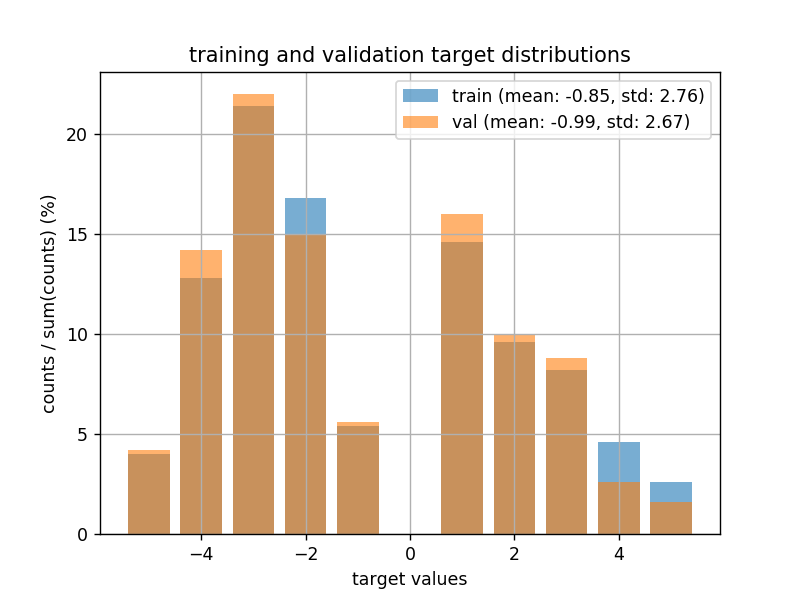

```python
target_is_continuous=False # target is not continuous, profile scores are discrete
normalization='over total' # heights=counts/sum(discrete_hist)
opacity=0.6
# end of inputs ---------------------------------------------------------------

plt.figure()
for phase in ['train','val']:
    targets_list=profiles_df.iloc[dataset_indices[phase]]['profile score'].values
    DatingAI.easy_hist(targets_list,distribution_is_continuous=target_is_continuous,
              normalization=normalization,label=phase,opacity=opacity)
plt.title('training and validation target distributions')
plt.xlabel('target values')
plt.legend(loc='best');
```

This figure presents a few important things:

- My scoring: integers from -5 to +5, without 0 for a practical reason - my *Personal Cupid Scraper* automatically likes/dislikes a profile if the score given by the user is positive/negative, to advance to the next profile that the site suggests. Zero stops the script (intentionally), it is unwanted since it is undetermined. I chose discrete scoring since I wanted to leave the option to perform classification.
- The training and validation distributions are similar enough, which is important.

## Tokenizing, building vocabularies

Since I deal with Israeli profiles, essays are written in English, Hebrew and Emojis - all mixed together. Hebrew is highly inflective (which makes it much more efficient and easy to learn than agglutinative languages, e.g. Latin languages), and my data is not too large, so **I chose to tokenize in character level!** I use all characters, including white spaces, stop words, punctuation, etc - which are required in character level.

### Vobacularies

1. Headlines vocabulary, e.g. {'My self-summary':0,'I Value':1,...}
2. Characters vobaculary, e.g. {'.':0,'a':1,...,'😁':100}

### Headline tokenizing

1. Building the vocabulary only according to the most common headlines that cover up to cumulative_portion_to_cover_with_headline_vocab of all train headlines.
2. Manually adding '<UNK>' for out-of-vocabulary tokens. Converting out-of-vocabulary headlines into '<UNK>' token.

String tokenizing into character tokens:

```python
logger.info('starting data tokenization')
essays_dict={}
for i_profile in range(len(profiles_df)):
    essay_dict=profiles_df['essay dict'].iloc[i_profile]
    tokenized_essay_dict={}
    for headline in essay_dict:
        string=essay_dict[headline]
        if lower_chars:
            string=string.lower(string)
        char_tokens_list=DatingAI.tokenize_essay_string(string)
        if len(char_tokens_list)>0:
            tokenized_essay_dict.update({headline:char_tokens_list})
    essays_dict.update({i_profile:tokenized_essay_dict})
logger.info('tokenized all text, starting to build character and headline vocabularies according to train data')

# building vocabularies according to train data
char_tokens_counter=Counter()
headline_tokens_counter=Counter()
for i_profile in train_indices:
    tokenized_essay_dict=essays_dict[i_profile]
    for headline in tokenized_essay_dict:
        headline_tokens_counter+=Counter([headline])
        char_tokens_list=tokenized_essay_dict[headline]
        char_tokens_counter+=Counter(char_tokens_list)

# building headline vocabulary
headline_most_common_tokens_df,headline_tokens_for_vocabulary_df=\
    DatingAI.build_most_common_tokens_df(headline_tokens_counter,cumulative_portion_to_cover_with_headline_vocab)
headline_token_to_id_dict={token:i for i,token in enumerate(headline_tokens_for_vocabulary_df['token'])}
headline_token_to_id_dict.update({'<UNK>':len(headline_token_to_id_dict)})
headline_id_to_token_dict={i:token for token,i in headline_token_to_id_dict.items()}
headline_vocab_size=len(headline_token_to_id_dict)
logger.info("built headline vocabulary according to train data, in length of %d, containing %d tokens that cover %.1f%% of the corpus, and '<UNK>'"%(
        headline_vocab_size,len(headline_tokens_for_vocabulary_df),100*cumulative_portion_to_cover_with_headline_vocab))

# building character vocabulary
char_most_common_tokens_df,char_tokens_for_vocabulary_df=\
    DatingAI.build_most_common_tokens_df(char_tokens_counter,cumulative_portion_to_cover_with_char_vocab)
char_token_to_id_dict={token:i for i,token in enumerate(char_tokens_for_vocabulary_df['token'])}
char_token_to_id_dict.update({'<UNK>':len(char_token_to_id_dict)})
for char_token in tokens_to_force_into_char_vobac:
    if char_token not in char_token_to_id_dict:
        char_token_to_id_dict.update({char_token:len(char_token_to_id_dict)})
char_id_to_token_dict={i:token for token,i in char_token_to_id_dict.items()}
char_vocab_size=len(char_token_to_id_dict)
logger.info("built character vocabulary according to train data, in length of %d, containing %d tokens that cover %.1f%% of the corpus, '<UNK>' and forced (only if not present) tokens: %s"%(
        char_vocab_size,len(char_tokens_for_vocabulary_df),
        100*cumulative_portion_to_cover_with_char_vocab,
        tokens_to_force_into_char_vobac))
```

```
2019-11-09 23:37:10 <module> (INFO): starting data tokenization
2019-11-09 23:37:10 <module> (INFO): tokenized all text, starting to build character and headline vocabularies according to train data
2019-11-09 23:37:10 <module> (INFO): built headline vocabulary according to train data, in length of 67, containing 66 tokens that cover 98.0% of the corpus, and '<UNK>'
2019-11-09 23:37:10 <module> (INFO): built character vocabulary according to train data, in length of 87, containing 77 tokens that cover 98.0% of the corpus, '<UNK>' and forced (only if not present) tokens: ['0', '1', '2', '3', '4', '5', '6', '7', '8', '9', '<br/>']
```

### Debugging: analyzing vocabularies

```
10 most common headline tokens:
```

|  | token | counts | portion | cumulative portion |
| --- | --- | --- | --- | --- |
| 0 | My self-summary | 421 | 0.399810 | 0.399810 |
| 1 | You should message me if | 44 | 0.041785 | 0.441595 |
| 2 | I value | 43 | 0.040836 | 0.482431 |
| 3 | What I'm doing with my life | 41 | 0.038936 | 0.521368 |
| 4 | What I'm actually looking for | 40 | 0.037987 | 0.559354 |
| 5 | Favorite books, movies, shows, music, and food | 32 | 0.030389 | 0.589744 |
| 6 | My golden rule | 30 | 0.028490 | 0.618234 |
| 7 | I'm really good at | 30 | 0.028490 | 0.646724 |
| 8 | Current goal | 29 | 0.027540 | 0.674264 |
| 9 | Six things I could never do without | 29 | 0.027540 | 0.701804 |

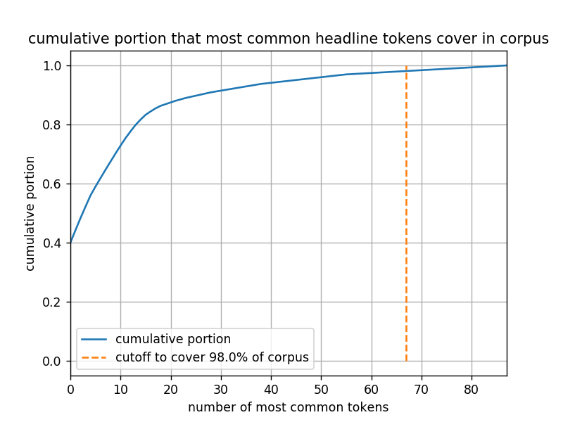

```
10 most common character tokens:
```

|  | token | counts | portion | cumulative portion |
| --- | --- | --- | --- | --- |
| 0 |  | 12923 | 0.156724 | 0.156724 |
| 1 | י | 4045 | 0.049056 | 0.205780 |
| 2 | ו | 3804 | 0.046133 | 0.251913 |
| 3 | e | 2899 | 0.035158 | 0.287071 |
| 4 | ה | 2477 | 0.030040 | 0.317111 |
| 5 | ל | 2434 | 0.029518 | 0.346629 |
| 6 | ת | 2352 | 0.028524 | 0.375153 |
| 7 | r | 2160 | 0.026195 | 0.401349 |
| 8 | א | 2136 | 0.025904 | 0.427253 |
| 9 | o | 2072 | 0.025128 | 0.452381 |

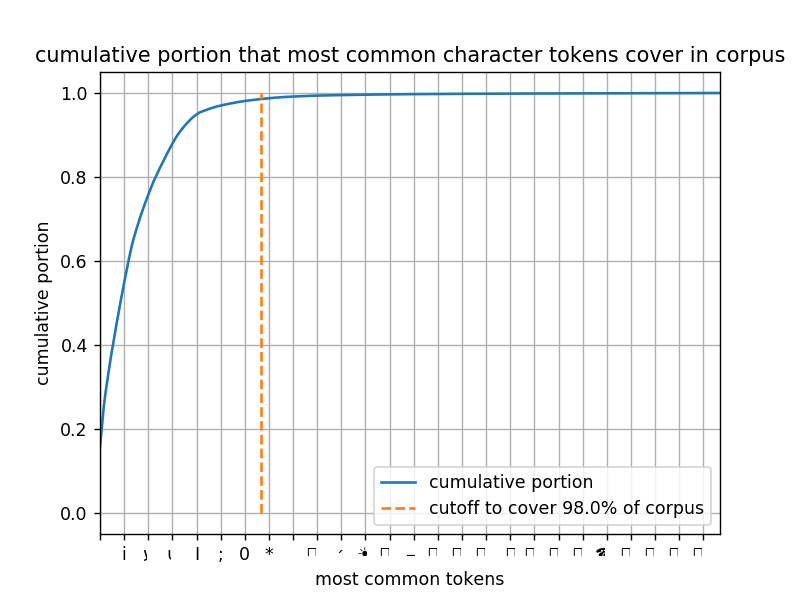

```python
n_most_common_tokens_to_print=10
char_xticks_period_over_tokens_len=0.04 # if >0: instead of numbers, showing tokens in x ticks, every xticks_period tokens, where xticks_period=round(xticks_period_over_tokens_len*len(most_common_tokens_df))
#xticks_period_over_tokens_len=0 # showing numbers in x ticks
# end of inputs ---------------------------------------------------------------

if debugging:
    DatingAI.analyze_vocabulary('headline',headline_most_common_tokens_df,
                       len(headline_token_to_id_dict),
                       cumulative_portion_to_cover_with_headline_vocab,
                       n_most_common_tokens_to_print,
                       xticks_period_over_tokens_len=0)
    DatingAI.analyze_vocabulary('character',char_most_common_tokens_df,
                           len(char_token_to_id_dict),
                           cumulative_portion_to_cover_with_char_vocab,
                           n_most_common_tokens_to_print,
                           char_xticks_period_over_tokens_len)
```

## Building dataset

*essays_dict* that contained headlineas and tokenized strings are now updated to contain headline indices and character indices, then a PyTorch dataset is built.

```python
logger.info('started converting all data from tokens to ids')
for i_profile in range(len(essays_dict)):
    tokenized_essay_dict=essays_dict[i_profile]
    tokenized_ids_essay_dict={}
    for headline in tokenized_essay_dict:
        char_tokens_list=tokenized_essay_dict[headline]
        char_token_ids_list=[]
        for char_token in char_tokens_list:
            if char_token in char_token_to_id_dict:
                char_token_ids_list.append(char_token_to_id_dict[char_token])
            else:
                char_token_ids_list.append(char_token_to_id_dict['<UNK>'])
        if headline in headline_token_to_id_dict:
            headline_token=headline_token_to_id_dict[headline]
        else:
            headline_token=headline_token_to_id_dict['<UNK>']
        tokenized_ids_essay_dict.update({headline_token:char_token_ids_list})
    essays_dict.update({i_profile:tokenized_ids_essay_dict})

dataset_to_split=DatingAI.essays_dataset(profiles_df,essays_dict)
logger.info('converted all data from tokens to ids, build dataset')
```

```
2019-11-09 23:37:10 <module> (INFO): started converting all data from tokens to ids
2019-11-09 23:37:10 <module> (INFO): converted all data from tokens to ids, build dataset
```

### Debugging: tokenized data stats

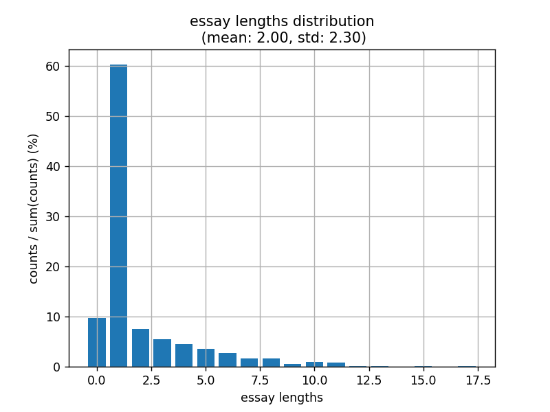

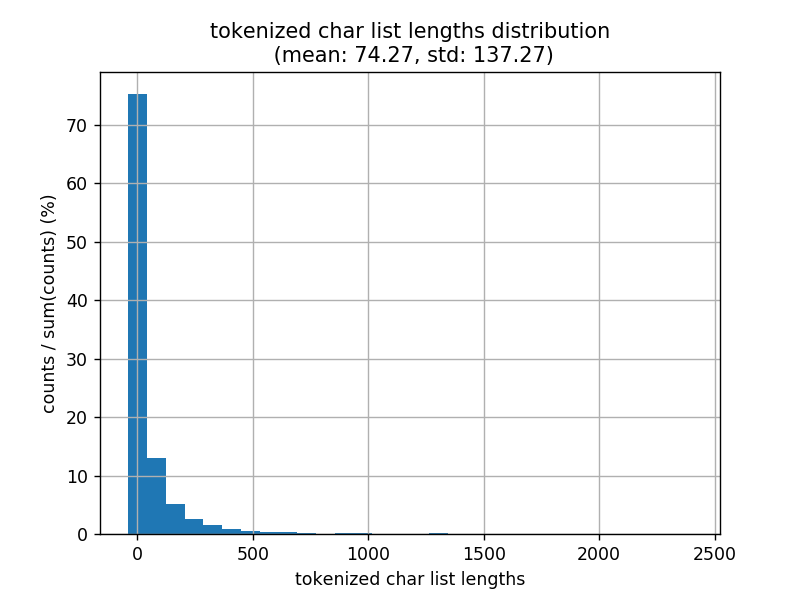

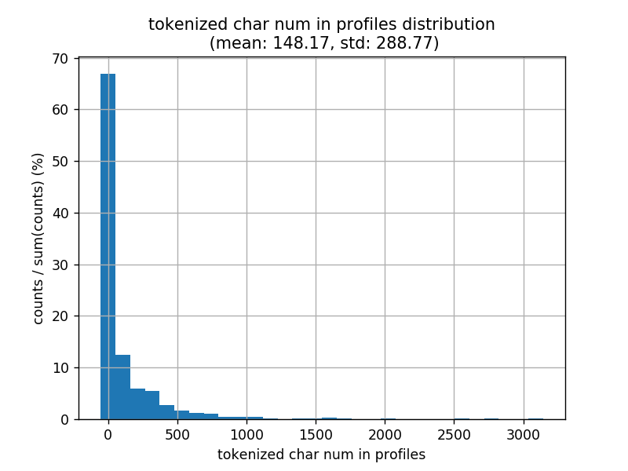

```python
normalization='over total' # heights=counts/sum(discrete_hist)
bins=30
# end of inputs ---------------------------------------------------------------

if debugging:
    tokenized_essay_lengths_list=[]
    tokenized_char_list_lengths_list=[]
    tokenized_chars_in_profile_list=[]
    for profile_id in essays_dict:
        essay_dict=essays_dict[profile_id]
        tokenized_essay_lengths_list.append(len(essay_dict))
        tokenized_chars_in_profile=0
        for headline_id in essay_dict:
            char_token_ids_list=essay_dict[headline_id]
            tokenized_char_list_length=len(char_token_ids_list)
            tokenized_char_list_lengths_list.append(tokenized_char_list_length)
            tokenized_chars_in_profile+=tokenized_char_list_length
        tokenized_chars_in_profile_list.append(tokenized_chars_in_profile)

    # plotting
    plt.figure()
    DatingAI.easy_hist(tokenized_essay_lengths_list,distribution_is_continuous=False,
              normalization=normalization,label='essay lengths')

    plt.figure()
    DatingAI.easy_hist(tokenized_char_list_lengths_list,distribution_is_continuous=True,bins=bins,
              normalization=normalization,label='tokenized char list lengths')

    plt.figure()
    DatingAI.easy_hist(tokenized_chars_in_profile_list,distribution_is_continuous=True,bins=bins,
              normalization=normalization,label='tokenized char num in profiles')
```

### Debugging: verifyign dataset, vocabularies

```python
samples_num_to_verify=5
samples_verification_seed=0
# samples_verification_seed=None # None means no pre-set seed
# end of inputs ---------------------------------------------------------------

if debugging:
    random.seed(samples_verification_seed)
    sampled_indices_list=random.sample(range(len(profiles_df)),samples_num_to_verify)
    for sample_i in sampled_indices_list:
        sample=dataset_to_split[sample_i]
        profile=profiles_df.iloc[sample_i]
        print('-'*30,f'analyzing data for profile {sample_i}','-'*30)
        print(f"---> original profile {sample_i} data: idx: {sample_i}, score: {profile['profile score']}, essay dict:",
              profile['essay dict'])
        print(f"\n---> PyTorch dataset sample {sample_i}: idx: {sample['profile idx']}, score: {sample['profile score']}, essay token ids:",
              sample['essay dict tokenized ids'])

        # untokenizing
        untokenized_ids_essay_dict={}
        for headline_token in sample['essay dict tokenized ids']:
            headline=headline_id_to_token_dict[headline_token]
            char_tokens=sample['essay dict tokenized ids'][headline_token]
            chars=[char_id_to_token_dict[char_token] for char_token in char_tokens]
            string=''.join(chars)
            untokenized_ids_essay_dict.update({headline:string})
        print(f"\n---> converting sample tokenized essay dict ids back into tokens:",
              untokenized_ids_essay_dict)
        print('\n')
```

```
------------------------------ analyzing data for profile 864 ------------------------------
---> original profile 864 data: idx: 864, score: -3.0, essay dict: {'My self-summary': '<p>אני בן אדם טוב ומצחיקה...  הייתי מעדיפה לא להיות פה לצערי התאלמנתי. הייתי מעדיפה שלא. נותנת הזדמנות נוספת לחיים. זה לא פשוט אבל משתדלת להצליח.  מורה לציור. שומרת את השאר לשיחה🙊  לא מעשנת ולא עושה סמים וזה די מ…

---> PyTorch dataset sample 864: idx: 864, score: -3.0, essay token ids: {0: [8, 21, 1, 0, 12, 49, 0, 8, 29, 25, 0, 39, 2, 12, 0, 2, 14, 44, 24, 1, 30, 4, 22, 22, 22, 0, 0, 4, 1, 1, 6, 1, 0, 14, 26, 29, 1, 35, 4, 0, 5, 8, 0, 5, 4, 1, 2, 6, 0, 35, 4, 0, 5, 44, 26, 16, 1, 0, 4, 6, 8, 5, 14, 21, 6, 1, …

---> converting sample tokenized essay dict ids back into tokens: {'My self-summary': 'אני בן אדם טוב ומצחיקה...  הייתי מעדיפה לא להיות פה לצערי התאלמנתי. הייתי מעדיפה שלא. נותנת הזדמנות נוספת לחיים. זה לא פשוט אבל משתדלת להצליח.  מורה לציור. שומרת את השאר לשיחה<UNK>  לא מעשנת ולא עושה סמים וזה די מ…


------------------------------ analyzing data for profile 394 ------------------------------
---> original profile 394 data: idx: 394, score: -4.0, essay dict: {'My self-summary': '<p>.היי אני שריי (sarai) בת 27 , תואר ראשון. אוהבת לבלות🍾🥂 בעיקר לטייל לא חשוב לאן 😊🙈 אוהבת בעלי חיים בעיקר כלבים - יש לי כלב אז בעקרון אנחנו חבילה אחת 😁🐾🐶🐕 גרה כשנה וחצי בתל אביב- אחלה עיר מתה על האווירה מחפשת ק…

---> PyTorch dataset sample 394: idx: 394, score: -4.0, essay token ids: {0: [22, 4, 1, 1, 0, 8, 21, 1, 0, 17, 16, 1, 1, 0, 61, 18, 10, 7, 10, 13, 53, 0, 12, 6, 0, 64, 83, 0, 19, 0, 6, 2, 8, 16, 0, 16, 8, 17, 2, 49, 22, 0, 8, 2, 4, 12, 6, 0, 5, 12, 5, 2, 6, 77, 77, 0, 12, 26, 1, 30, 16, 0, 5, 39, 1,…

---> converting sample tokenized essay dict ids back into tokens: {'My self-summary': '.היי אני שריי (sarai) בת 27 , תואר ראשון. אוהבת לבלות<UNK><UNK> בעיקר לטייל לא חשוב לאן <UNK><UNK> אוהבת בעלי חיים בעיקר כלבים - יש לי כלב אז בעקרון אנחנו חבילה אחת <UNK><UNK><UNK><UNK> גרה כשנה וחצי בתל אביב- אחל…


------------------------------ analyzing data for profile 776 ------------------------------
---> original profile 776 data: idx: 776, score: -3.0, essay dict: {'My self-summary': '<p>קיבוצניקית (ליד כפר סבא) בת 29, בעלת תואר ראשון (אם חשוב). עובדת כQA. אוהבת מוזיקה (לנגן ולשמוע, לא כדאי שאשיר), לשבת עם חברים, לשמור על כושר (מחשבתי ופיזי), לקרוא ספרים, טיולים. בוגרת, תומכת, מכילה, אכפתית. א…

---> PyTorch dataset sample 776: idx: 776, score: -3.0, essay token ids: {0: [30, 1, 12, 2, 44, 21, 1, 30, 1, 6, 0, 61, 5, 1, 29, 0, 32, 35, 16, 0, 42, 12, 8, 53, 0, 12, 6, 0, 64, 85, 19, 0, 12, 26, 5, 6, 0, 6, 2, 8, 16, 0, 16, 8, 17, 2, 49, 0, 61, 8, 25, 0, 24, 17, 2, 12, 53, 22, 0, 26, 2, 12, 29, …

---> converting sample tokenized essay dict ids back into tokens: {'My self-summary': 'קיבוצניקית (ליד כפר סבא) בת 29, בעלת תואר ראשון (אם חשוב). עובדת כ<UNK>A. אוהבת מוזיקה (לנגן ולשמוע, לא כדאי שאשיר), לשבת עם חברים, לשמור על כושר (מחשבתי ופיזי), לקרוא ספרים, טיולים. בוגרת, תומכת, מכילה, אכפתית. א…


------------------------------ analyzing data for profile 911 ------------------------------
---> original profile 911 data: idx: 911, score: -2.0, essay dict: {'My self-summary': '<p>❤</p>'}

---> PyTorch dataset sample 911: idx: 911, score: -2.0, essay token ids: {0: [77]}

---> converting sample tokenized essay dict ids back into tokens: {'My self-summary': '<UNK>'}


------------------------------ analyzing data for profile 430 ------------------------------
---> original profile 430 data: idx: 430, score: 1.0, essay dict: {'My self-summary': '<p>...</p>'}

---> PyTorch dataset sample 430: idx: 430, score: 1.0, essay token ids: {0: [22, 22, 22]}

---> converting sample tokenized essay dict ids back into tokens: {'My self-summary': '...'}
```

## Splitting to train,val datasets and dataloaders

**Batching in training is done on profiles, but texts are not batched by tensors of fixed shape**, since the tokenized_ids_essay_dict for each profile is of arbitrary length (number of headline keys), and their itmes - char_token_ids_list - are lists of arbitrary length. Therefore, **I wrote a custom collate function for PyTorch dataloaders to stack tokenized_ids_essay_dicts into a list** (since the default collate function stacks into tensors).

I also use my custom collate to stack `'profile idx'` into lists instead of tensors. In this notebook `'profile idx'` contains profile indices of raw profiles_df which are integers and therefore can be stacked into a tensor, but originally `'profile idx'` is meant to contain profile ids (ommitted here for privacy), which are strings, and PyTorch raises an error if collating too long strings into tensors...

```python
dataset_features_to_leave_unstacked=['essay dict tokenized ids','profile idx']
# end of inputs ---------------------------------------------------------------

custom_collate_fn=DatingAI.collate_samples_into_batch_functional(dataset_features_to_leave_unstacked)

if isinstance(batch_size_int_or_ratio_float,int):
    batch_size=batch_size_int_or_ratio_float
elif isinstance(batch_size_int_or_ratio_float,float):
    batch_size=round(batch_size_int_or_ratio_float*len(dataset_to_split))
else:
    raise RuntimeError('unsupported batch_size input!')
if batch_size<1:
    batch_size=1
    logger.warning('batch_size=round(batch_size_over_dataset_length*len(dataset_to_split))<1 so batch_size=1 was set')
if batch_size==1:
    user_batch_size=input('got batch_size=1, may cause errors, enter a new batch size equal or larger than 1, or smaller than 1 to abort: ')
    if user_batch_size<1:
        raise RuntimeError('aborted by user batch size decision')
    else:
        batch_size=round(user_batch_size)

# splitting the dataset to train and val
train_dataset=ptdata.Subset(dataset_to_split,train_indices)
val_dataset=ptdata.Subset(dataset_to_split,val_indices)

# creating the train and val dataloaders
train_dataloader=ptdata.DataLoader(train_dataset,batch_size=batch_size,
                        num_workers=data_workers,shuffle=dataloader_shuffle,
                        collate_fn=custom_collate_fn)
val_dataloader=ptdata.DataLoader(val_dataset,batch_size=batch_size,
                        num_workers=data_workers,shuffle=dataloader_shuffle,
                        collate_fn=custom_collate_fn)

# structuring
dataset_indices={'train':train_indices,'val':val_indices}
datasets={'train':train_dataset,'val':val_dataset}
dataset_samples_number={'train':len(train_dataset),'val':len(val_dataset)}

dataloaders={'train':train_dataloader,'val':val_dataloader}
dataloader_batches_number={'train':len(train_dataloader),'val':len(val_dataloader)}

logger.info('dataset split to training and validation datasets and dataloaders with validation_ratio=%.1f, lengths: (train,val)=(%d,%d)'%(
        validation_ratio,dataset_samples_number['train'],dataset_samples_number['val']))
```

```
2019-11-09 23:37:10 <module> (INFO): dataset split to training and validation datasets and dataloaders with validation_ratio=0.5, lengths: (train,val)=(500,500)
```

## Debugging: verifying dataloaders

```python
if debugging:
    if __name__=='__main__' or data_workers==0:
        batches={}
        for phase in ['train','val']:
            batch=next(iter(dataloaders[phase]))
            batches.update({phase:batch})
    else:
        logger.warning('notice: cannot use multiprocessing (data_workers>0 in dataloaders) in Windows when executed not as main')

    for phase in ['train','val']:
        print('-'*20,f'{phase} batch','-'*20)
        batch=batches[phase]
        print(batch)
```

```
-------------------- train batch --------------------
{'profile idx': [908, 632, 229, 646, 391, 920, 620, 378], 'profile score': tensor([-3., -3., -2., -3.,  1.,  4.,  3.,  5.]), 'essay dict tokenized ids': [{0: [29, 21, 1, 8, 5, 0, 5, 2, 1, 19, 0, 64, 80, 19, 0, 16, 14, 6, 0, 46, 49, 0, 0, 8, 2, 4, 12, 6, 0, 5, 39, 1, 1, 5, 19, 0, 5, 8, 32, 2, 5, 0, 3…
-------------------- val batch --------------------
{'profile idx': [359, 146, 586, 973, 772, 965, 289, 173], 'profile score': tensor([-1.,  2., -2., -3., -3.,  3., -4., -3.]), 'essay dict tokenized ids': [{0: [5, 16, 30, 2, 29, 0, 32, 5, 0, 4, 5, 1, 5, 4, 0, 26, 29, 0, 17, 32, 2, 8, 12, 2, 6, 0, 4, 16, 46, 5, 1, 1, 25, 36, 23, 7, 33, 37, 36, 23, 7, …
```

# Setting the model

The model architecture is described in the scheme in # Intro.

## Batching in the nets

1. Since char_LSTM gets a (char) sequence of arbitrary length per sample, no batching can be done with rectangular tensors, it processes one sample at a time (batch_size=1).
2. attention_on_char_biLSTM gets a dictionary (tokenized_ids_essay_dict) of an arbitrary size per sample, and therefore no batching also for it.
3. Batching is done for batch_regression_on_attention that gets a batch, and sends each tokenized_ids_essay_dict to an attention net.

```python
char_model=DatingAI.char_LSTM_net(LSTM_hidden_size,LSTM_layers,bidirectional,
                 char_embedding_dim,char_vocab_size).to(device)
attention_model=DatingAI.attention_on_char_biLSTM_net(char_model,headline_embedding_dim,
                                headline_vocab_size,attention_size).to(device)
model=DatingAI.batch_regression_on_attention_net(attention_model).to(device)

parameters_to_optimize=model.parameters()
total_weights_num=sum(p.numel() for p in model.parameters())
trainable_weights_num=sum(p.numel() for p in model.parameters() if p.requires_grad)
logger.info("model set on %s, trainable/total weigths: %.1e/%.1e"%(
    device,trainable_weights_num,total_weights_num))

if loss_name=='MSE, reduction: sum':
    loss_fn=nn.MSELoss(reduction='sum').to(device)
else:
    raise RuntimeError('untreated loss_name input')
if optimizer_name=='SGD':
    optimizer=torch.optim.SGD(parameters_to_optimize,lr=learning_rate,momentum=SGD_momentum)
elif optimizer_name=='Adam':
    optimizer=torch.optim.Adam(parameters_to_optimize,lr=learning_rate,betas=Adam_betas)
else:
    raise RuntimeError('untreated optimizer_name input')

scheduler=torch.optim.lr_scheduler.StepLR(optimizer,
    step_size=lr_scheduler_step_size,gamma=lr_scheduler_decay_factor)
```

```
2019-11-09 23:37:13 <module> (INFO): model set on cuda:0, trainable/total weigths: 6.4e+03/6.4e+03
```

## Debugging: verifying model architecture

```python
if debugging:
    if __name__=='__main__' or data_workers==0:
        batch=next(iter(dataloaders['train']))
        labels=batch['profile score'].float()
        labels=labels.to(device)
        print('labels:',labels)
    else:
        logger.warning('notice: cannot use multiprocessing (data_workers>0 in dataloaders) in Windows when executed not as main')

    tokenized_ids_essay_dict_list=batch['essay dict tokenized ids']

    # complete model debugging
    print('\n','-'*20,'complete model debugging ','-'*20)
    predicted_scores=model(tokenized_ids_essay_dict_list)
    print('predicted_scores.shape:',predicted_scores.shape)

    # attention net debugging
    print('\n','-'*10,'attention net debugging (on tokenized_ids_essay_dict of the last sample in batch)','-'*10)
    print('length (number of headlines) of tokenized_ids_essay_dict:',len(tokenized_ids_essay_dict))

    attention_out=attention_model(tokenized_ids_essay_dict)
    print('attention_out.shape:',attention_out.shape)

    # char biLSTM debugging
    if len(tokenized_ids_essay_dict)==0:
        print('len(tokenized_ids_essay_dict)==0')
    else:
        print('\n','-'*10,'char biLSTM debugging (on the first section in the last sample in batch)','-'*10)
        headline_id=list(tokenized_ids_essay_dict.keys())[0]
        char_token_ids_list=tokenized_ids_essay_dict[headline_id]
        print('len(char_token_ids_list):',len(char_token_ids_list))
        char_token_ids_tensor=torch.tensor([char_token_ids_list]).to(device).long().transpose(0,1)
        chars_embedded=char_model.char_embedding(char_token_ids_tensor)
        char_model.init_hidden()
        outputs_sequence,(last_hidden_state,last_cell_state)=char_model(char_token_ids_tensor)
        last_hidden_state_squeeezed=last_hidden_state.squeeze()
        if bidirectional:
            last_hidden_state_squeeezed=torch.sum(last_hidden_state_squeeezed,dim=0)

        print('chars_embedded.shape:',chars_embedded.shape)
        print('outputs_sequence.shape:',outputs_sequence.shape)
        print('last_hidden_state.shape:',last_hidden_state.shape)
        print('last_cell_state.shape:',last_cell_state.shape)
        print('last_hidden_state.shape:',last_hidden_state.shape)
        print('last_hidden_state_squeeezed.shape:',last_hidden_state_squeeezed.shape)
```

```
labels: tensor([-2., -2., -3.,  1.,  1., -3.,  1., -1.], device='cuda:0')

 -------------------- complete model debugging  --------------------
predicted_scores.shape: torch.Size([8, 1])

 ---------- attention net debugging (on tokenized_ids_essay_dict of the last sample in batch) ----------
length (number of headlines) of tokenized_ids_essay_dict: 0
attention_out.shape: torch.Size([1, 4])
len(tokenized_ids_essay_dict)==0
```

# Training the model, analysis

## Training

Training an LSTM (or any RNN) on PyTorch is a bit tricky, since hidden vectors (state and cell) must be repackaged before starting a new sequence (before they are being initialized). To understand why and what happens if not, read my documentation of char_model.repackage_hidden() method.

```python
def model_evaluation(model,dataloader,dataset_samples_number,loss_fn):
    model.eval() # set model to evaluate mode

    epoch_loss=0.0 # must be a float
    epoch_samples_number=0
    label_arrays_list=[]
    output_arrays_list=[]

    for i_batch,batch in enumerate(dataloader):
        labels=batch['profile score'].to(device).unsqueeze(1).float()
        tokenized_ids_essay_dict_list=batch['essay dict tokenized ids']

        # forward
        with torch.set_grad_enabled(False): # if phase=='train' it tracks tensor history for grad calc
            outputs=model(tokenized_ids_essay_dict_list)
            loss=loss_fn(outputs,labels)

        # accumulating
        samples_number=len(labels)
        epoch_samples_number+=samples_number
        current_loss=loss.item()
        epoch_loss+=current_loss

        label_arrays_list.append(labels.flatten().cpu().numpy())
        output_arrays_list.append(outputs.flatten().cpu().numpy())

    # post-processing
    epoch_loss_per_sample=epoch_loss/dataset_samples_number
    labels_array=np.concatenate(label_arrays_list)
    outputs_array=np.concatenate(output_arrays_list)
    return labels_array,outputs_array,epoch_loss_per_sample

# if force_train_evaluation_after_each_epoch:
#     train_evaluation_ui=input('force_train_evaluation_after_each_epoch=True was set, it is unrequired and increases training time (but useful for analysis), approve? y/[n] ')
#     if train_evaluation_ui!='y':
#         raise RuntimeError('user did not approve force_train_evaluation_after_each_epoch=True, aborting!')

if plot_realtime_stats_on_logging or plot_realtime_stats_after_each_epoch:
    logger.warning('plotting from inside the net loop is not working, should be debugged...')

if train_model_else_load_weights and (__name__=='__main__' or data_workers==0):
    stats_dict={'train':{'running metrics':{},'epoch total running metrics':{},
                         'evaluation metrics':{}},
                     'val':{'evaluation metrics':{}}}


    if torch.cuda.is_available():
        logger.info('torch is using %s (%s)'%(device,torch.cuda.get_device_name(device=0)))
    else:
        logger.info('torch is using %s'%(device))

    # model pre-training evaluation
    if pre_training_evaluation:
        logger.info('started model pre-training evaluation')
        for phase in ['train','val']:
            dataloader=dataloaders[phase]
            labels_array,outputs_array,epoch_loss_per_sample=\
                    model_evaluation(model,dataloaders[phase],
                                        dataset_samples_number[phase],loss_fn)
            errors_array=labels_array-outputs_array
            epoch_MSE=(errors_array**2).mean()
            logger.info('(pre-training, %s) loss per sample: %.3e, sqrt(MSE): sqrt(%.3e)=%.3e'%(
                            phase,epoch_loss_per_sample,epoch_MSE,epoch_MSE**0.5))
            stats_dict[phase]['evaluation metrics'].update({0:
                                {'loss per sample':epoch_loss_per_sample,
                                 'MSE':epoch_MSE}})

    total_batches=epochs*(dataloader_batches_number['train']+dataloader_batches_number['val'])
    period_already_logged=0
    logger.info('started model training')
    print('-'*10)
    tic=time()

    # model training
    for epoch in range(epochs):
        for phase in ['train','val']:
            if phase=='train':
                model.train() # set model to training mode
            else:
                model.eval() # set model to evaluate mode

            epoch_loss=0.0 # must be a float
            epoch_squared_error=0.0
            samples_processed_since_last_log=0
            loss_since_last_log=0.0 # must be a float
            squared_error_since_last_log=0.0

            for i_batch,batch in enumerate(dataloaders[phase]):
                labels=batch['profile score'].to(device).unsqueeze(1).float()
                tokenized_ids_essay_dict_list=batch['essay dict tokenized ids']

                optimizer.zero_grad() # zero the parameter gradients

                # forward
                with torch.set_grad_enabled(phase=='train'): # if phase=='train' it tracks tensor history for grad calc
                    outputs=model(tokenized_ids_essay_dict_list)
                    loss=loss_fn(outputs,labels)
                    if torch.isnan(loss):
                        raise RuntimeError('reached NaN loss - aborting training!')
                    # backward + optimize if training
                    if phase=='train':
                        loss.backward()
                        optimizer.step()
                        scheduler.step()

                # accumulating stats
                samples_number=len(labels)
                samples_processed_since_last_log+=samples_number

                current_loss=loss.item()
                epoch_loss+=current_loss
                loss_since_last_log+=current_loss

                with torch.set_grad_enabled(False):
                    batch_squared_error=((outputs-labels)**2).sum().item()
                epoch_squared_error+=batch_squared_error
                squared_error_since_last_log+=batch_squared_error

                # logging running stats
                if phase=='train' and period_in_seconds_to_log_loss>0:
                    passed_seconds=time()-tic
                    period=passed_seconds//period_in_seconds_to_log_loss
                    if period>period_already_logged:
                        period_already_logged=period
                        loss_since_last_log_per_sample=loss_since_last_log/samples_processed_since_last_log
                        MSE_since_last_log=squared_error_since_last_log/samples_processed_since_last_log

                        completed_batches=epoch*(dataloader_batches_number['train']+dataloader_batches_number['val'])+(i_batch+1)
                        completed_batches_progress=completed_batches/total_batches

                        logger.info('(epoch %d/%d, batch %d/%d, %s, running) loss per sample : %.3e, sqrt(MSE): sqrt(%.3e)=%.3e'%(
                                    epoch+1,epochs,i_batch+1,dataloader_batches_number[phase],phase,
                                    loss_since_last_log_per_sample,
                                    MSE_since_last_log,MSE_since_last_log**0.5))

                        partial_epoch=epoch+completed_batches_progress
                        stats_dict[phase]['running metrics'].update({partial_epoch:
                            {'batch':i_batch+1,'loss per sample':loss_since_last_log_per_sample,
                             'MSE':MSE_since_last_log}})

                        loss_since_last_log=0.0 # must be a float
                        squared_error_since_last_log=0.0
                        samples_processed_since_last_log=0

            # accumulating epoch stats
            epoch_loss_per_sample=epoch_loss/dataset_samples_number[phase]
            epoch_MSE=epoch_squared_error/dataset_samples_number[phase]

            if phase=='train': # saving running stats
                stats_dict[phase]['epoch total running metrics'].update({epoch+1:
                            {'loss per sample':epoch_loss_per_sample,
                             'MSE':epoch_MSE}})
                if force_train_evaluation_after_each_epoch: # evaluating train dataloader
                    labels_array,outputs_array,epoch_loss_per_sample=\
                        model_evaluation(model,dataloaders[phase],
                                        dataset_samples_number[phase],loss_fn)
                    errors_array=labels_array-outputs_array
                    epoch_MSE=(errors_array**2).mean()
                    stats_dict[phase]['evaluation metrics'].update({epoch+1:
                            {'loss per sample':epoch_loss_per_sample,
                             'MSE':epoch_MSE}})
            else: # val dataloader evaluation
                stats_dict[phase]['evaluation metrics'].update({epoch+1:
                            {'loss per sample':epoch_loss_per_sample,
                             'MSE':epoch_MSE}})

            if phase=='val': # updating best model results
                if best_model_criterion=='min val epoch MSE':
                    best_criterion_current_value=epoch_MSE
                    if epoch==0:
                        best_criterion_best_value=best_criterion_current_value
                        best_model_wts=copy.deepcopy(model.state_dict())
                        best_epoch=epoch
                    else:
                        if best_criterion_current_value<best_criterion_best_value:
                            best_criterion_best_value=best_criterion_current_value
                            best_model_wts=copy.deepcopy(model.state_dict())
                            best_epoch=epoch

            # logging evaluation stats
            if phase=='val' or force_train_evaluation_after_each_epoch:
                logger.info('(epoch %d/%d, %s, evaluation) epoch loss per sample: %.3e, epoch sqrt(MSE): sqrt(%.3e)=%.3e'%(
                                    epoch+1,epochs,phase,
                                    epoch_loss_per_sample,
                                    epoch_MSE,epoch_MSE**0.5))

        # logging ETA in the end of each epoch
        completed_epochs_progress=(epoch+1)/epochs
        passed_seconds=time()-tic
        expected_seconds=passed_seconds/completed_epochs_progress*(1-completed_epochs_progress)
        expected_remainder_time=DatingAI.remainder_time(expected_seconds)
        logger.info('Progress: %.2f%%, ETA: %dh:%dm:%.0fs'%(
                                100*completed_epochs_progress,
                                expected_remainder_time.hours,
                                expected_remainder_time.remainder_minutes,
                                expected_remainder_time.remainder_seconds))
        print('-'*10)
    toc=time()
    elapsed_sec=toc-tic

    logger.info('finished training %d epochs in %dm:%.1fs'%(
            epochs,elapsed_sec//60,elapsed_sec%60))
    if return_to_best_weights_in_the_end:
        model.load_state_dict(best_model_wts)
        logger.info("loaded weights of best model according to '%s' criterion: best value %.3f achieved in epoch %d"%(
                best_model_criterion,best_criterion_best_value,best_epoch+1))

else: # train_model_else_load_weights==False
    model_name_ui=input('model weights file name to load: ')
    model_weights_file_path=os.path.join(models_folder_path,model_name_ui)
    if not os.path.isfile(model_weights_file_path):
        raise RuntimeError('%model_weights_path does not exist!')
    model_weights=torch.load(model_weights_file_path)
    model.load_state_dict(model_weights)
    logger.info('model weights from %s were loaded'%model_weights_file_path)
```

```
2019-11-09 23:37:14 <module> (INFO): torch is using cuda:0 (GeForce GTX 960M)
2019-11-09 23:37:14 <module> (INFO): started model pre-training evaluation
2019-11-09 23:37:18 <module> (INFO): (pre-training, train) loss per sample: 8.711e+00, sqrt(MSE): sqrt(8.711e+00)=2.951e+00
2019-11-09 23:37:21 <module> (INFO): (pre-training, val) loss per sample: 8.542e+00, sqrt(MSE): sqrt(8.542e+00)=2.923e+00
2019-11-09 23:37:21 <module> (INFO): started model training
```

```
2019-11-09 23:37:35 <module> (INFO): (epoch 1/10, train, evaluation) epoch loss per sample: 8.254e+00, epoch sqrt(MSE): sqrt(8.254e+00)=2.873e+00
2019-11-09 23:37:38 <module> (INFO): (epoch 1/10, val, evaluation) epoch loss per sample: 8.016e+00, epoch sqrt(MSE): sqrt(8.016e+00)=2.831e+00
2019-11-09 23:37:38 <module> (INFO): Progress: 10.00%, ETA: 0h:2m:34s
```

```
2019-11-09 23:37:52 <module> (INFO): (epoch 2/10, train, evaluation) epoch loss per sample: 7.868e+00, epoch sqrt(MSE): sqrt(7.868e+00)=2.805e+00
2019-11-09 23:37:56 <module> (INFO): (epoch 2/10, val, evaluation) epoch loss per sample: 7.545e+00, epoch sqrt(MSE): sqrt(7.545e+00)=2.747e+00
2019-11-09 23:37:56 <module> (INFO): Progress: 20.00%, ETA: 0h:2m:18s
```

```
2019-11-09 23:37:56 <module> (INFO): (epoch 3/10, batch 1/63, train, running) loss per sample : 8.750e+00, sqrt(MSE): sqrt(8.750e+00)=2.958e+00
2019-11-09 23:38:10 <module> (INFO): (epoch 3/10, train, evaluation) epoch loss per sample: 7.718e+00, epoch sqrt(MSE): sqrt(7.718e+00)=2.778e+00
2019-11-09 23:38:13 <module> (INFO): (epoch 3/10, val, evaluation) epoch loss per sample: 7.329e+00, epoch sqrt(MSE): sqrt(7.329e+00)=2.707e+00
2019-11-09 23:38:13 <module> (INFO): Progress: 30.00%, ETA: 0h:2m:2s
```

```
2019-11-09 23:38:21 <module> (INFO): (epoch 4/10, batch 53/63, train, running) loss per sample : 7.768e+00, sqrt(MSE): sqrt(7.768e+00)=2.787e+00
2019-11-09 23:38:27 <module> (INFO): (epoch 4/10, train, evaluation) epoch loss per sample: 7.686e+00, epoch sqrt(MSE): sqrt(7.686e+00)=2.772e+00
2019-11-09 23:38:31 <module> (INFO): (epoch 4/10, val, evaluation) epoch loss per sample: 7.274e+00, epoch sqrt(MSE): sqrt(7.274e+00)=2.697e+00
2019-11-09 23:38:31 <module> (INFO): Progress: 40.00%, ETA: 0h:1m:45s
```

```
2019-11-09 23:38:45 <module> (INFO): (epoch 5/10, train, evaluation) epoch loss per sample: 7.677e+00, epoch sqrt(MSE): sqrt(7.677e+00)=2.771e+00
2019-11-09 23:38:49 <module> (INFO): (epoch 5/10, val, evaluation) epoch loss per sample: 7.257e+00, epoch sqrt(MSE): sqrt(7.257e+00)=2.694e+00
2019-11-09 23:38:49 <module> (INFO): Progress: 50.00%, ETA: 0h:1m:28s
```

```
2019-11-09 23:38:51 <module> (INFO): (epoch 6/10, batch 18/63, train, running) loss per sample : 8.529e+00, sqrt(MSE): sqrt(8.529e+00)=2.920e+00
2019-11-09 23:39:03 <module> (INFO): (epoch 6/10, train, evaluation) epoch loss per sample: 7.673e+00, epoch sqrt(MSE): sqrt(7.673e+00)=2.770e+00
2019-11-09 23:39:06 <module> (INFO): (epoch 6/10, val, evaluation) epoch loss per sample: 7.258e+00, epoch sqrt(MSE): sqrt(7.258e+00)=2.694e+00
2019-11-09 23:39:06 <module> (INFO): Progress: 60.00%, ETA: 0h:1m:10s
```

```
2019-11-09 23:39:20 <module> (INFO): (epoch 7/10, train, evaluation) epoch loss per sample: 7.667e+00, epoch sqrt(MSE): sqrt(7.667e+00)=2.769e+00
2019-11-09 23:39:24 <module> (INFO): (epoch 7/10, val, evaluation) epoch loss per sample: 7.253e+00, epoch sqrt(MSE): sqrt(7.253e+00)=2.693e+00
2019-11-09 23:39:24 <module> (INFO): Progress: 70.00%, ETA: 0h:0m:52s
```

```
2019-11-09 23:39:24 <module> (INFO): (epoch 8/10, batch 1/63, train, running) loss per sample : 9.727e+00, sqrt(MSE): sqrt(9.727e+00)=3.119e+00
2019-11-09 23:39:37 <module> (INFO): (epoch 8/10, train, evaluation) epoch loss per sample: 7.671e+00, epoch sqrt(MSE): sqrt(7.671e+00)=2.770e+00
2019-11-09 23:39:41 <module> (INFO): (epoch 8/10, val, evaluation) epoch loss per sample: 7.248e+00, epoch sqrt(MSE): sqrt(7.248e+00)=2.692e+00
2019-11-09 23:39:41 <module> (INFO): Progress: 80.00%, ETA: 0h:0m:35s
```

```
2019-11-09 23:39:54 <module> (INFO): (epoch 9/10, train, evaluation) epoch loss per sample: 7.667e+00, epoch sqrt(MSE): sqrt(7.667e+00)=2.769e+00
2019-11-09 23:39:58 <module> (INFO): (epoch 9/10, val, evaluation) epoch loss per sample: 7.238e+00, epoch sqrt(MSE): sqrt(7.238e+00)=2.690e+00
2019-11-09 23:39:58 <module> (INFO): Progress: 90.00%, ETA: 0h:0m:17s
```

```
2019-11-09 23:39:58 <module> (INFO): (epoch 10/10, batch 1/63, train, running) loss per sample : 9.517e+00, sqrt(MSE): sqrt(9.517e+00)=3.085e+00
2019-11-09 23:40:12 <module> (INFO): (epoch 10/10, train, evaluation) epoch loss per sample: 7.660e+00, epoch sqrt(MSE): sqrt(7.660e+00)=2.768e+00
2019-11-09 23:40:15 <module> (INFO): (epoch 10/10, val, evaluation) epoch loss per sample: 7.234e+00, epoch sqrt(MSE): sqrt(7.234e+00)=2.690e+00
2019-11-09 23:40:15 <module> (INFO): Progress: 100.00%, ETA: 0h:0m:0s
```

```
2019-11-09 23:40:15 <module> (INFO): finished training 10 epochs in 2m:54.2s
2019-11-09 23:40:16 <module> (INFO): loaded weights of best model according to 'min val epoch MSE' criterion: best value 7.234 achieved in epoch 10
```

## Analyzing training statistics

### My definitions

- **Running stats** - measured each time running stats are logged (set by periond_in_seconds_to_log_loss) for the training dataset samples that were trained since the last running stats logging!
- **Epoch total running stats** - averaging all running stats on all the training dataset. Notice that these stats are measured along training, while the weights are being trained!
- **Evaluation stats** - measured in each epoch after training completes (model in evaluation mode)! For the training dataset, evaluation stats are optional and can be avoided to save time (by setting force_train_evaluation_after_each_epoch=False).

### What to expect

I started this project for my interest, challenge, experience. **"Great" results are not any of the goals, and not expected, since:**

- I don't care to play around with hyper-parameters.
- I demonstrate results on a quite small dataset.
- I trained only a short time (a few epochs).
- **There are many other features in a profile except for text that are not treated here**: images, age, height...

```
2019-11-09 23:40:16 <module> (INFO): remember that even if loss_name='MSE', the loss may include regularization or auxiliary terms and therefore may not equal MSE!
```

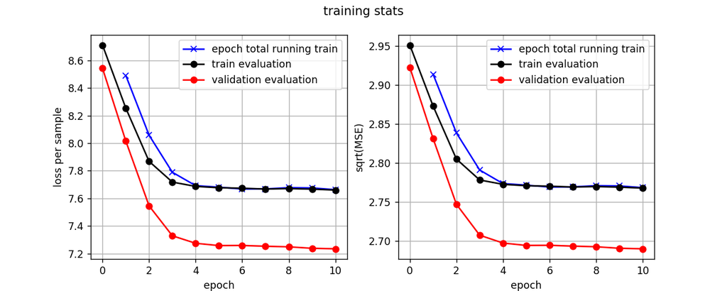

```python
# plot_running_stats=True
plot_running_stats=False
plot_epoch_total_running_stats=True
# plot_epoch_total_running_stats=False
plot_y_in_log_scale=False
# plot_y_in_log_scale=True
figure_size=(10,4) # (width,height) in inches
# end of inputs ---------------------------------------------------------------

logger.info("remember that even if loss_name='MSE', the loss may include regularization or auxiliary terms and therefore may not equal MSE!")
if not (plot_realtime_stats_on_logging or plot_realtime_stats_after_each_epoch):
    fig=plt.figure(figsize=figure_size)
    plt.suptitle('training stats')
    loss_subplot=plt.subplot(1,2,1)
    MSE_subplot=plt.subplot(1,2,2)
    DatingAI.training_stats_plot(stats_dict,fig,loss_subplot,MSE_subplot,plot_y_in_log_scale,
                        plot_running_stats,plot_epoch_total_running_stats)
```

### Analyzing results

# Post-training model evaluation

```
2019-11-09 23:40:16 <module> (INFO): started model evaluation
```

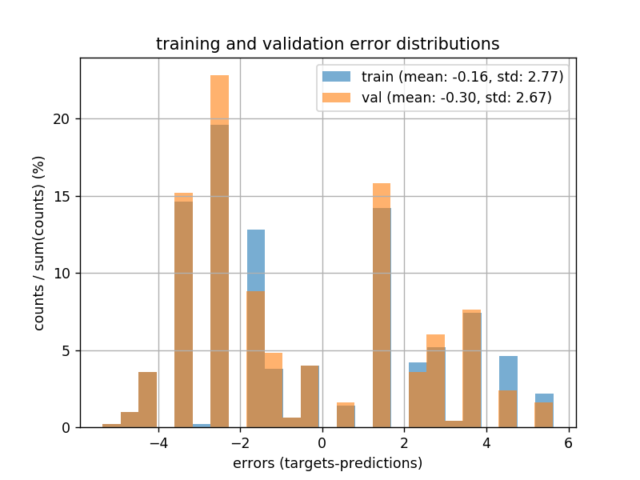

```
2019-11-09 23:40:20 <module> (INFO): (post-training, train) loss per sample: 7.670e+00, sqrt(MSE): sqrt(7.670e+00)=2.769e+00
2019-11-09 23:40:24 <module> (INFO): (post-training, val) loss per sample: 7.240e+00, sqrt(MSE): sqrt(7.240e+00)=2.691e+00
2019-11-09 23:40:24 <module> (INFO): completed model evaluation
```

```python
distribution_is_continuous=True # target is not continuous, profile scores are discrete
normalization='over total' # heights=counts/sum(discrete_hist)
opacity=0.6
bins=25
# end of inputs ---------------------------------------------------------------

logger.info('started model evaluation')
plt.figure()
for phase in ['train','val']:
    dataloader=dataloaders[phase]
    labels_array,outputs_array,epoch_loss_per_sample=\
                        model_evaluation(model,dataloaders[phase],
                                        dataset_samples_number[phase],loss_fn)
    errors_array=labels_array-outputs_array
    DatingAI.easy_hist(errors_array,distribution_is_continuous=True,bins=bins,
              normalization=normalization,label=phase,opacity=opacity)
    epoch_MSE=(errors_array**2).mean()
    logger.info('(post-training, %s) loss per sample: %.3e, sqrt(MSE): sqrt(%.3e)=%.3e'%(
                    phase,epoch_loss_per_sample,epoch_MSE,epoch_MSE**0.5))

logger.info('completed model evaluation')
plt.title('training and validation error distributions')
plt.xlabel('errors (targets-predictions)')
plt.legend(loc='best');
```

## Analyzing error distributions

- After returning to the best validation MSE during training, we see in the figure that the training and validation error distributions are quite similar - indeed no strong over-fitting.
- **The errors are distributed around discrete peaks that belong to "typical confusions" between the same discrete targets.**

```python
logger.info('completed script')
```

```
2019-11-09 23:40:24 <module> (INFO): completed script
```

# Saving model weights

```python
if offer_mode_saving and train_model_else_load_weights:
    try: os.mkdir(models_folder_path)
    except FileExistsError: pass # if the folder exists already - do nothing

    saving_decision=input('save model weights? [y]/n ')
    if saving_decision!='n':
        model_name_ui=input('name model weights file: ')
        model_weights_file_path=os.path.join(models_folder_path,model_name_ui+'.ptweights')
        if os.path.isfile(model_weights_file_path):
            alternative_filename=input('%s already exists, give a different file name to save, the same file name to over-write, or hit enter to abort: '%model_weights_file_path)
            if alternative_filename=='':
                raise RuntimeError('aborted by user')
            else:
                model_weights_file_path=os.path.join(models_folder_path,alternative_filename+'.ptweights')
        torch.save(model.state_dict(),model_weights_file_path)
        logger.info('%s saved'%model_weights_file_path)
```